# Marathon

Svetlana Yakub

# **Анализ данных с помощью программы R**

## Связь между демографическими параметрами и успехом в забеге марафона

### 1.Анализ датасета Dataset-Boston-2019.csv, скаченного со страницы www.kaggle.com/

### Чтобы иметь возможность проводить анализ данных и получать графические изображения загружаем и устанавливаем следующие пакеты и библиотеки: #install.packages("ggplot2") library(ggplot2) #install.packages("DT") library(DT) #install.packages("GGally") library(GGally) #install.packages("mosaic") library(mosaic) #install.packages("doBy") library(doBy) #install.packages("RcmdrMisc") #install.packages("rcmdr") library(RcmdrMisc) library(car) #install.packages("plotrix") library(plotrix) Для анализа csv-файл был загружен с помощью следующей команды: library(tidyverse) Marathon <- read.csv("C:/Users/CC-Student.MININT-BQ5DQM7/Desktop/Dataset-Boston-2019.csv") DT::datatable(Marathon) 1.1 Описание переменных Следующая команда дает обзор переменных и их характеристик. Можно увидеть, например, что у нас данные по 26651 участнику забега, распределенные по 8 переменным с типом данных «int» для числовой и «chr» для номинальной информации. str(Marathon) ## 'data.frame': 26651 obs. of 8 variables: ## $ Rank_Tot : int 1 2 3 4 5 6 7 8 9 10 ... ## $ Age : int 30 29 34 32 26 28 27 30 24 28 ... ## $ Gender : chr "M" "M" "M" "M" ... ## $ Country : chr "Kenya" "Ethiopia" "Kenya" "Kenya" ... ## $ Result_hr : chr "2:07:57" "2:07:59" "2:08:07" "2:08:54" ... ## $ Result_sec : int 7677 7679 7687 7734 7735 7737 7749 7765 7765 7793 ... ## $ Rank_Gender : int 1 2 3 4 5 6 7 8 9 10 ... ## $ Country_code: chr "KEN" "ETH" "KEN" "KEN" ... Чтобы проводить дальнейшие исследования необходимо было сгенерировать еще две переменные: net_hr <- Marathon$Result_sec/3600 Marathon <- cbind (Marathon,net_hr) km_per_hour <- 42/net_hr Marathon <- cbind (Marathon,km_per_hour) summary(Marathon) ## Rank_Tot Age Gender Country ## Min. : 1 Min. :18.0 Length:26651 Length:26651 ## 1st Qu.: 6664 1st Qu.:34.0 Class :character Class :character ## Median :13327 Median :43.0 Mode :character Mode :character ## Mean :13327 Mean :42.8 ## 3rd Qu.:19990 3rd Qu.:51.0 ## Max. :26652 Max. :83.0 ## Result_hr Result_sec Rank_Gender Country_code ## Length:26651 Min. : 7677 Min. : 1 Length:26651 ## Class :character 1st Qu.:12026 1st Qu.: 3332 Class :character ## Mode :character Median :13534 Median : 6664 Mode :character ## Mean :13980 Mean : 6731 ## 3rd Qu.:15538 3rd Qu.: 9995 ## Max. :25197 Max. :14671 ## net_hr km_per_hour ## Min. :2.132 Min. : 6.001 ## 1st Qu.:3.340 1st Qu.: 9.731 ## Median :3.759 Median :11.172 ## Mean :3.883 Mean :11.200 ## 3rd Qu.:4.316 3rd Qu.:12.573 ## Max. :6.999 Max. :19.695 1.2 Построим различные диаграммы и вытащим различную информацию: q <- qplot(Marathon$Country, xlab="Country", ylab = "Number of Participants", main="Histogram Country of Origin") q + theme(axis.text.x = element_text(angle = 90, hjust = 1, size = 5)) count(Marathon, Country) ## Country n ## 1 Afghanistan 1 ## 2 Albania 4 ## 3 Algeria 1 ## 4 Andorra 1 ## 5 Antigua and Barbuda 1 ## 6 Argentina 61 ## 7 Australia 271 ## 8 Austria 45 ## 9 Barbados 1 ## 10 Belarus 4 ## 11 Belgium 68 ## 12 Bermuda 2 ## 13 Bhutan 2 ## 14 Bolivia 3 ## 15 Bosnia and Herzegovina 2 ## 16 Brazil 308 ## 17 Bulgaria 1 ## 18 Cambodia 1 ## 19 Canada 1753 ## 20 Cayman Islands 1 ## 21 Chile 71 ## 22 China 529 ## 23 Colombia 106 ## 24 Costa Rica 74 ## 25 Croatia 4 ## 26 Cuba 1 ## 27 Cyprus 2 ## 28 Czech Republic 22 ## 29 Denmark 79 ## 30 Dominican Republic 13 ## 31 Ecuador 11 ## 32 Egypt 3 ## 33 El Salvador 11 ## 34 Eritrea 1 ## 35 Estonia 13 ## 36 Ethiopia 7 ## 37 Finland 42 ## 38 France 234 ## 39 Georgia 1 ## 40 Germany 302 ## 41 Greece 8 ## 42 Guatemala 40 ## 43 Guyana 1 ## 44 Honduras 9 ## 45 Hong Kong 132 ## 46 Hungary 15 ## 47 Iceland 15 ## 48 India 86 ## 49 Indonesia 11 ## 50 Ireland 205 ## 51 Israel 17 ## 52 Italy 184 ## 53 Jamaica 1 ## 54 Japan 313 ## 55 Jordan 1 ## 56 Kazakhstan 1 ## 57 Kenya 19 ## 58 Korea, Republic of 156 ## 59 Kuwait 1 ## 60 Latvia 4 ## 61 Lebanon 1 ## 62 Lithuania 16 ## 63 Luxembourg 7 ## 64 Macao 5 ## 65 Malaysia 11 ## 66 Malta 1 ## 67 Mexico 426 ## 68 Moldova 2 ## 69 Monaco 1 ## 70 Morocco 17 ## 71 Namibia 1 ## 72 Nepal 2 ## 73 Netherlands 138 ## 74 New Zealand 62 ## 75 Nicaragua 1 ## 76 Norway 41 ## 77 Pakistan 1 ## 78 Palestine 1 ## 79 Panama 8 ## 80 Paraguay 1 ## 81 Peru 35 ## 82 Philippines 23 ## 83 Poland 76 ## 84 Portugal 48 ## 85 Puerto Rico 8 ## 86 Romania 6 ## 87 Russia 49 ## 88 Serbia and Montenegro 2 ## 89 Singapore 30 ## 90 Slovakia 12 ## 91 Slovenia 11 ## 92 South Africa 38 ## 93 Spain 267 ## 94 Sri Lanka 1 ## 95 Sweden 72 ## 96 Switzerland 88 ## 97 Taiwan 171 ## 98 Thailand 17 ## 99 Trinidad and Tobago 5 ## 100 Turkey 12 ## 101 Uganda 1 ## 102 Ukraine 13 ## 103 United Arab Emirates 1 ## 104 United Kingdom 705 ## 105 United States 18902 ## 106 Uruguay 2 ## 107 Uzbekistan 1 ## 108 Venezuela 34 ## 109 Vietnam 2 mean(Marathon$net_hr) ## [1] 3.883349 qplot(Marathon$Age, geom = "histogram", bindwidth = 5, main = "Histogram Age", ylab = "Number of Participants", xlab = "Age") barplot(table(Marathon$Gender), col=c("pink","lightblue"), main = "Bar graph male to female ratio", ylab = "Number of participants", xlab = "Gender", ylim = c(0,15500)) options(repr.plot.width=12, repr.plot.height=7) Marathon_gen = table(Marathon$Gender) gen <- pie3D(Marathon_gen, labels=c(paste('Female'), paste('Male')), main='Gender distribution', explode = 0.12, start=2, theta=0.9, labelcex=2.0, cex.main=2, radius=0.9 ) boxplot(Age ~ Gender, Marathon) qplot(Marathon$km_per_hour, geom = "histogram", bindwidth = 5, main = "Speed destribution histogram ", ylab = "Number of participants", xlab = "km/h") mean(Marathon$km_per_hour ) ## [1] 11.20048 dotPlot(~net_hr, nint=50, data=Marathon, main = "Run time distribution diagram", ylab = "Number of participants", xlab = "Run time in h")

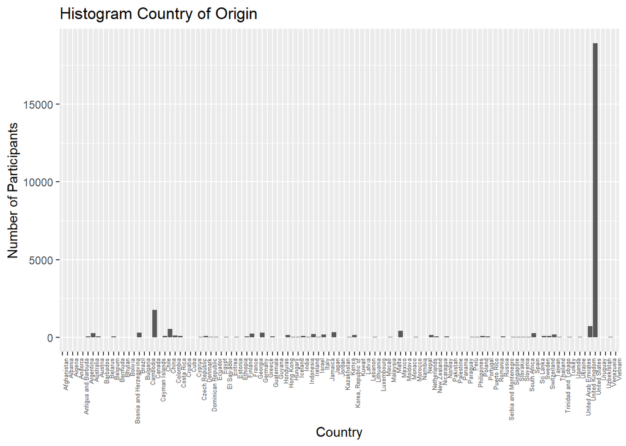

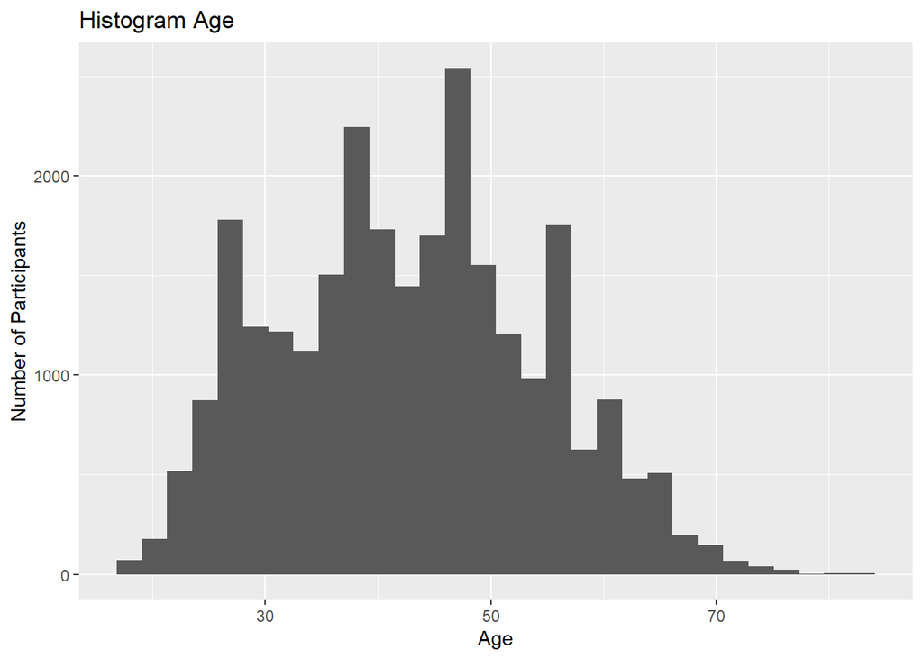

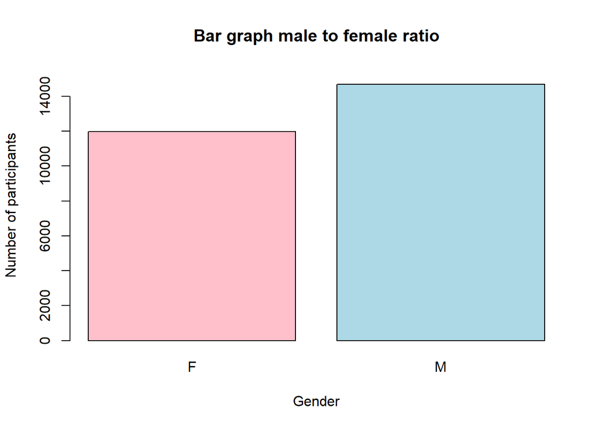

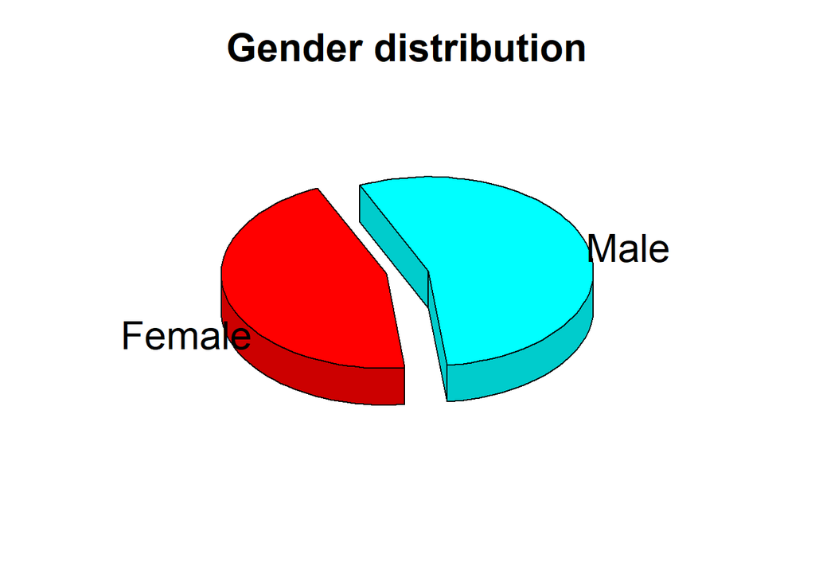

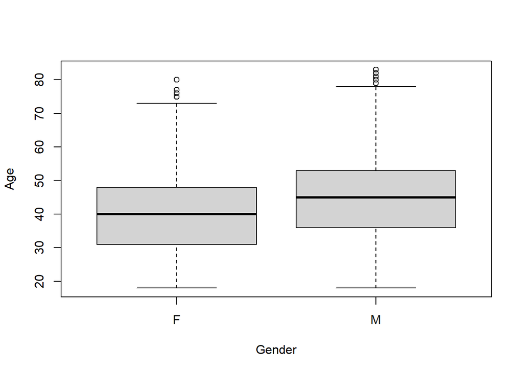

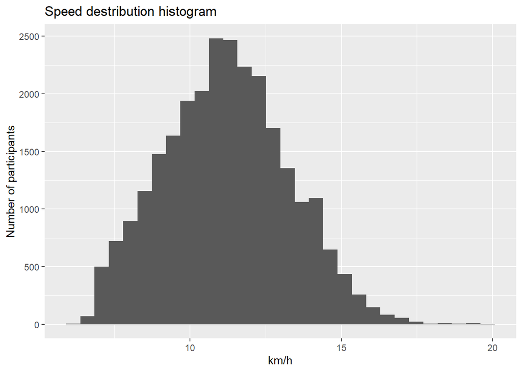

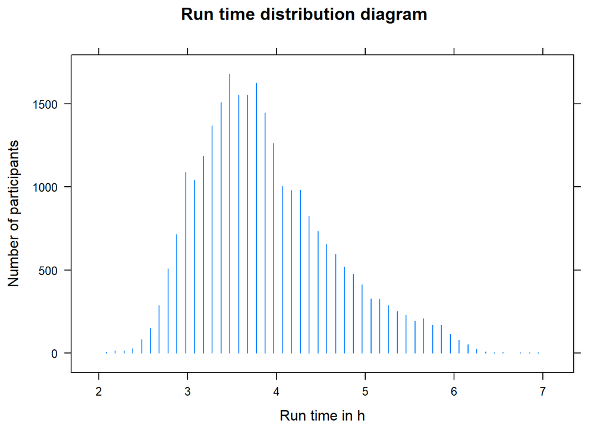

## **2. Дедуктивный анализ гипотез**

### 2.1 Успех зависит от возраста

### H1: Чем старше бегун, тем больше времени ему требуется H0: Более страший возраст не имеет никакого влияния на время пробега Чтобы проверить эту гипотезу, переменная Age необходима как независимая переменная и net_hours как зависимая. Гипотеза утверждает, что эти переменные имеют положительную корреляцию, то есть бегунам старшего возраста нужно больше времени для бега на данную дистанцию, чем бегунам младшего возраста. Строим диаграмму разброса по возрасту и продолжительности забега: xyplot(net_hr~Age, data = Marathon, main="Scatter Plot Age and run duration in hours", xlab = "Age", ylab = "Run duration in h", col = "tan2") и высчитываем коэффициент корреляции: rcorr.adjust(Marathon[,c("net_hr", "Age")], type="pearson", use = "complete") ## ## Pearson correlations: ## net_hr Age ## net_hr 1.000 0.261 ## Age 0.261 1.000 ## ## Number of observations: 26651 ## ## Pairwise two-sided p-values: ## net_hr Age ## net_hr <.0001 ## Age <.0001 ## ## Adjusted p-values (Holm's method) ## net_hr Age ## net_hr <.0001 ## Age <.0001 Он составляет 0,261 и показывает низкую положительную корреляцию, таким образом, усиливает интерпретацию диаграммы разброса, поскольку облако точек имеет более горизонтальную форму, чем вертикальную. regression_age<-lm(net_hr~Age, data = Marathon) summary(regression_age) ## ## Call: ## lm(formula = net_hr ~ Age, data = Marathon) ## ## Residuals: ## Min 1Q Median 3Q Max ## -1.5989 -0.5257 -0.1413 0.3743 3.1834 ## ## Coefficients: ## Estimate Std. Error t value Pr(>|t|) ## (Intercept) 3.1577129 0.0170261 185.46 <2e-16 *** ## Age 0.0169542 0.0003841 44.14 <2e-16 *** ## --- ## Signif. codes: 0 '***' 0.001 '**' 0.01 '*' 0.05 '.' 0.1 ' ' 1 ## ## Residual standard error: 0.7234 on 26649 degrees of freedom ## Multiple R-squared: 0.06813, Adjusted R-squared: 0.0681 ## F-statistic: 1948 on 1 and 26649 DF, p-value: < 2.2e-16 Здесь видно, что наклон линии регрессии очень небольшой, но все же положительный(0,0169542). Качество прогноза можно определить по multiple R-squared, которое здесь достаточно низкое - 0.06813. Таким образом прогноз регрессионной модели только приблизительно хорош, как если бы для прогноза использовалось среднее значение времени пробега. Теперь строим график линии регрессии зависимости возраста и времени пробега: library(car) scatterplot(net_hr~Age, boxplots=FALSE, xlab="Age", ylab="Duration", main="Regression line of Age and time", smooth=FALSE, data=Marathon) Таким образом можно сделать вывод, что H1 подтверждается на основе положительного наклона линии регрессии и низкого p-значения, а H0 отбрасывается. Возраст влияет на успех бегунов.

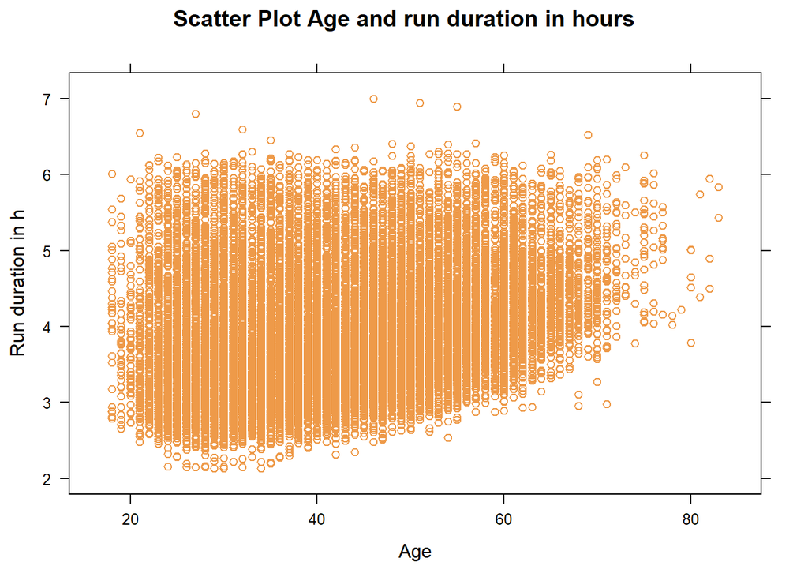

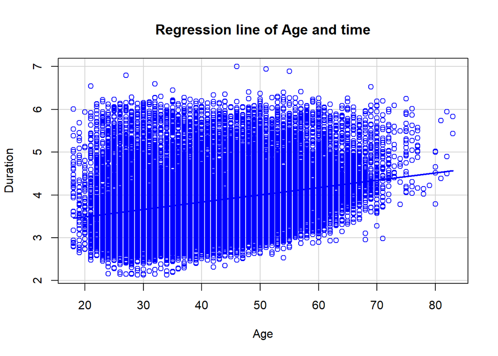

### 2.2 Успех зависит от пола

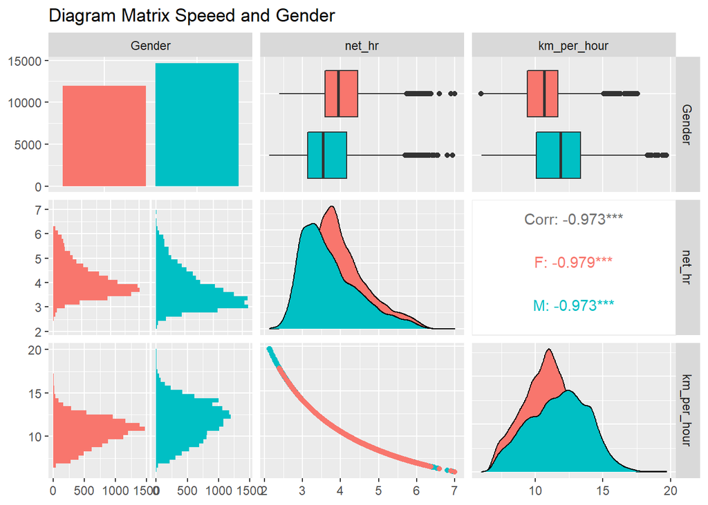

### **Спасибо за внимание!**